# ASM - Exercise week 11

Tobias Krüger & Anne-Kathleen Malchow

May 17, 2021

# 13E2

$$\begin{align*}
y_i &\sim {\sf Binomial}(1, p_i) \\
{\sf logit}(p_i) &= \alpha_{GROUP[i]} + \beta \cdot x_i \\
\alpha_j &\sim {\sf Normal}(\bar\alpha, \sigma) \\
\bar\alpha &\sim {\sf Normal}(0, 1.5) \\
\sigma &\sim {\sf Exponential}(1) \\
\beta &\sim {\sf Normal}(0, 0.5) \\
\end{align*}$$

# 13E3

$$\begin{align*}
y_i &\sim {\sf Normal}(\mu_i, \sigma) \\
\mu_i &= \alpha_{GROUP[i]} + \beta \cdot x_i \\
\alpha_j &\sim {\sf Normal}(\bar\alpha, \sigma_{\alpha}) \\
\bar\alpha &\sim {\sf Normal}(0, 5) \\
\sigma_{\alpha} &\sim {\sf Exponential}(1) \\
\beta &\sim {\sf Normal}(0, 1) \\
\sigma &\sim {\sf Exponential}(1) \\
\end{align*}$$

Note: The notation $\alpha_{GROUP[i]}$ followed by $\alpha_j$ might be unusual at first. What it means is that $GROUP[i]$ is an index variable with an index value for every data point $i$. But there are only so many values $j$ that the index variable can assume, which are in the shorter vector $\alpha$. In other words, $GROUP[i]$ points to certain values in the vector $\alpha$.

# 13M1

## Q:

Revisit the Reed frog survival data, `data(reedfrogs)`, and add the `predation` and `size` treatment variables to the varying intercepts model. Consider models with either main effect alone (*M1* and *M2*), both main effects (*M3*), as well as a model including both and their interaction (*M4*). Instead of focusing on inferences about these two predictor variables, focus on the inferred variation across tanks. Explain why it changes as it does across models.

## A:

We look at the following models, adapted from the model on page 403. Note that `brms` uses a non-centered intercept parameterisation for the distribution of the varying intercepts, so that $\bar \alpha$ is a population level effect:

$$\begin{align*}
\mathcal{M}_1: \,\, S_i &\sim {\sf Binomial}(N_i, p_i) \\
{\sf logit}(p_i) &= \bar \alpha + \alpha_{TANK[i]} + \beta_P \cdot pred \\
\alpha_j &\sim {\sf Normal}(0, \sigma) \\
\bar \alpha &\sim {\sf Normal}(0, 1.5) \\
\beta_P &\sim {\sf Normal}(0, 0.5) \\
\sigma &\sim {\sf Exponential}(1)\\
& \\
\mathcal{M}_2: \,\, S_i &\sim {\sf Binomial}(N_i, p_i) \\
{\sf logit}(p_i) &= \bar \alpha + \alpha_{TANK[i]} + \beta_S \cdot size \\
\alpha_j &\sim {\sf Normal}(0, \sigma) \\
\bar \alpha &\sim {\sf Normal}(0, 1.5) \\
\beta_S &\sim {\sf Normal}(0, 0.5) \\
\sigma &\sim {\sf Exponential}(1)\\
& \\
\mathcal{M}_3: \,\, S_i &\sim {\sf Binomial}(N_i, p_i) \\
{\sf logit}(p_i) &= \bar \alpha + \alpha_{TANK[i]} + \beta_P \cdot pred + \beta_S \cdot size \\
\alpha_j &\sim {\sf Normal}(0, \sigma) \\
\bar \alpha &\sim {\sf Normal}(0, 1.5) \\
\beta_P &\sim {\sf Normal}(0, 0.5) \\
\beta_S &\sim {\sf Normal}(0, 0.5) \\
\sigma &\sim {\sf Exponential}(1)\\
& \\
\mathcal{M}_4: \,\, S_i &\sim {\sf Binomial}(N_i, p_i) \\
{\sf logit}(p_i) &= \bar \alpha + \alpha_{TANK[i]} + \beta_P \cdot pred + \beta_S \cdot size + \beta_{PS} \cdot pred \cdot size \\
\alpha_j &\sim {\sf Normal}(0, \sigma) \\
\bar \alpha &\sim {\sf Normal}(0, 1.5) \\
\beta_P &\sim {\sf Normal}(0, 0.5) \\
\beta_S &\sim {\sf Normal}(0, 0.5) \\
\beta_{PS} &\sim {\sf Normal}(0, 0.5) \\
\sigma &\sim {\sf Exponential}(1)
\end{align*}$$

Load the dataset:

```r
library(rethinking)
data(reedfrogs)
d <- reedfrogs
```

Make the `tank` cluster variable (see R code 13.2, page 402):

```r
d$tank <- 1:nrow(d)
str(d)
```

```
## 'data.frame':    48 obs. of  6 variables:
##  $ density : int  10 10 10 10 10 10 10 10 10 10 ...
##  $ pred    : Factor w/ 2 levels "no","pred": 1 1 1 1 1 1 1 1 2 2 ...
##  $ size    : Factor w/ 2 levels "big","small": 1 1 1 1 2 2 2 2 1 1 ...
##  $ surv    : int  9 10 7 10 9 9 10 9 4 9 ...
##  $ propsurv: num  0.9 1 0.7 1 0.9 0.9 1 0.9 0.4 0.9 ...
##  $ tank    : int  1 2 3 4 5 6 7 8 9 10 ...
```

Fit the models:

```r
library(brms)

m.13M3.1 <-
  brm(data = d,
      family = binomial(link = "logit"),
      surv | trials(density) ~ 1 + pred + (1 | tank),
      prior = c(prior(normal(0, 1.5), class = Intercept), # prior for alpha bar
                prior(normal(0, 0.5), class = b, coef = 'predpred'),
                prior(exponential(1), class = sd, group = 'tank'))) # prior for sd controlling pooling across clusters

m.13M3.1 <- add_criterion(m.13M3.1, "waic")

m.13M3.2 <-
  brm(data = d,
      family = binomial(link = "logit"),
      surv | trials(density) ~ 1 + size + (1 | tank),
      prior = c(prior(normal(0, 1.5), class = Intercept),
                prior(normal(0, 0.5), class = b, coef = 'sizesmall'),
                prior(exponential(1), class = sd, group = 'tank')))

m.13M3.2 <- add_criterion(m.13M3.2, "waic")

m.13M3.3 <-
  brm(data = d,
      family = binomial(link = "logit"),
      surv | trials(density) ~ 1 + pred + size + (1 | tank),
      prior = c(prior(normal(0, 1.5), class = Intercept),
                prior(normal(0, 0.5), class = b, coef = 'predpred'),
                prior(normal(0, 0.5), class = b, coef = 'sizesmall'),
                prior(exponential(1), class = sd, group = 'tank')))

m.13M3.3 <- add_criterion(m.13M3.3, "waic")

m.13M3.4 <-
  brm(data = d,
      family = binomial(link = "logit"),
      surv | trials(density) ~ 1 + pred * size + (1 | tank),
      prior = c(prior(normal(0, 1.5), class = Intercept),
                prior(normal(0, 0.5), class = b, coef = 'predpred'),
                prior(normal(0, 0.5), class = b, coef = 'sizesmall'),
                prior(normal(0, 0.5), class = b, coef = 'predpred:sizesmall'),
                prior(exponential(1), class = sd, group = 'tank')))

m.13M3.4 <- add_criterion(m.13M3.4, "waic")
```

Check priors again:

```r
prior_summary(m.13M3.4)
```

```
##                 prior     class               coef group resp dpar nlpar bound
##                (flat)         b
##        normal(0, 0.5)         b           predpred
##        normal(0, 0.5)         b predpred:sizesmall
##        normal(0, 0.5)         b          sizesmall
##        normal(0, 1.5) Intercept
##  student_t(3, 0, 2.5)        sd
##        exponential(1)        sd                     tank
##        exponential(1)        sd          Intercept  tank
##        source
##       default
##          user
##          user
##          user
##          user
##       default
##          user
##  (vectorized)
```

Also refit the model from the chapter (without predictors) for comparison:

```r
m.13M3.5 <-
  brm(data = subset(d, select=c('surv','density','tank')),
      family = binomial(link = "logit"),
      surv | trials(density) ~ 1 + (1 | tank),
      prior = c(prior(normal(0, 1.5), class = Intercept),
                prior(exponential(1), class = sd, group = 'tank')))

m.13M3.5 <- add_criterion(m.13M3.5, "waic")
```

Inferred variation across tanks:

```r
models <- list(m.13M3.1,m.13M3.2,m.13M3.3,m.13M3.4,m.13M3.5)

group_variation <- sapply(1:5, function(m){
    x <- posterior_summary(models[[m]], probs = c(0.07,0.93))
    x["sd_tank__Intercept",]})

colnames(group_variation) <- c('m.13M3.1','m.13M3.2','m.13M3.3','m.13M3.4','m.13M3.5')
(group_variation <- data.frame(t(group_variation)))
```

```
##           Estimate Est.Error        Q7      Q93
## m.13M3.1 0.9017413 0.1671148 0.6805634 1.155853
## m.13M3.2 1.6149573 0.2155383 1.3232833 1.944687
## m.13M3.3 0.8619332 0.1733403 0.6282181 1.127096
## m.13M3.4 0.8795610 0.1744599 0.6405885 1.144351
## m.13M3.5 1.6194856 0.2089263 1.3342904 1.944878
```

Plot this:

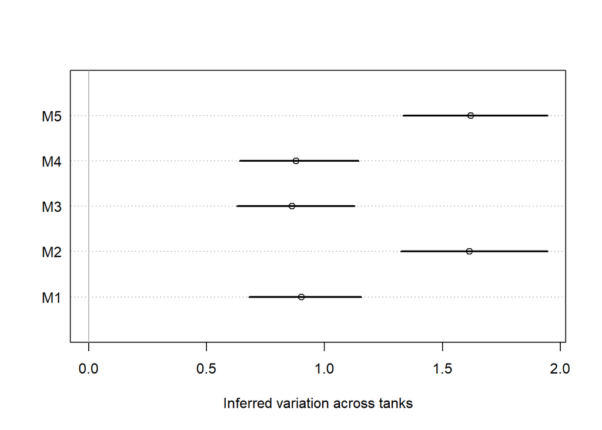

```r
with(group_variation, {
    dotchart(Estimate, labels = sapply(1:5, function(m){paste0('M',m)}),
             xlab = "Inferred variation across tanks",
             xlim = c(0,max(Q93)) )
    for (i in 1:length(models)) lines(c(Q7[i], Q93[i]), c(i,i), lwd = 2, col = "black")
    abline(v = 0, lty = 1, col = "grey70")
})
```

The models with single predictor `size`, *M2*, finds a similar variation across tanks than the varying intercepts-only model, *M5*. These models ascribe a lot of the variation in survival rates to a random cluster effect; `size` doesn’t seem to have a strong effect.

The models which include the predictor `predation`, *M1*, *M3* and *M4*, in contrast, find a clearly smaller cluster variation, because a certain amount of the variation in survival rates is explained with the treatment predictor `predation`. Including `size` on top of `predation` doesn’t add much (reduce the cluster variation). Including the interaction term certainly changes virtually nothing.

# 13M2

## Q:

Compare the models you fit just above, using WAIC. Can you reconcile the differences in WAIC with the posterior distributions of the models?

## A:

We have computed the WAICs already above with the model fits. Now compare:

```r
loo_compare(m.13M3.1,m.13M3.2,m.13M3.3,m.13M3.4,m.13M3.5, criterion = "waic")
```

```
##          elpd_diff se_diff
## m.13M3.4  0.0       0.0
## m.13M3.1 -0.4       0.7
## m.13M3.5 -0.5       2.0
## m.13M3.3 -0.6       0.3
## m.13M3.2 -1.0       2.0
```

```r
m.13M3.1 <- add_criterion(m.13M3.1, "loo", reloo = T)
m.13M3.2 <- add_criterion(m.13M3.2, "loo", reloo = T)
m.13M3.3 <- add_criterion(m.13M3.3, "loo", reloo = T)
m.13M3.4 <- add_criterion(m.13M3.4, "loo", reloo = T)
m.13M3.5 <- add_criterion(m.13M3.5, "loo", reloo = T)
```

```r
loo_compare(m.13M3.1,m.13M3.2,m.13M3.3,m.13M3.4,m.13M3.5, criterion = "loo")
```

```
##          elpd_diff se_diff
## m.13M3.4   0.0       0.0
## m.13M3.3  -2.6       1.3
## m.13M3.1  -3.2       2.1
## m.13M3.5 -18.3       3.5
## m.13M3.2 -18.6       3.3
```

The results are consistent with the plot above: models *M1*, *M3* and *M4* (the ones that include `pred` as predictor) perform best and pretty much equally well. Models *M2* and *M5* (with only `size` or no predictor) have much less predictive power.

Finally, let’s plot the simplest of the best-performing models, *M1*:

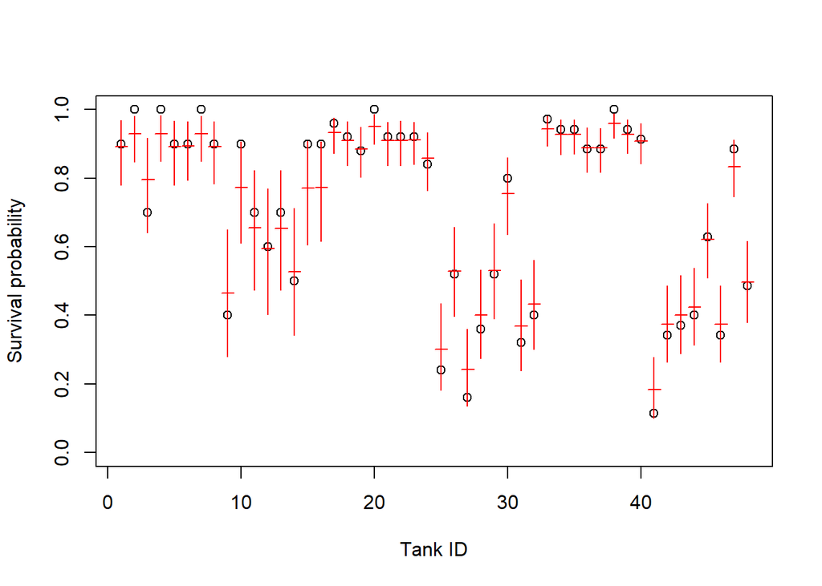

```r
# mean response at survival probability scale
fitd <- fitted(m.13M3.1, scale = "response", probs = c(0.07,0.93)) / d$density
# plot with central 86% compatibility interval
plot(d$tank, d$propsurv,
     ylim = c(0,1),
     xlab = "Tank ID",
     ylab = "Survival probability")
lines(d$tank, fitd[,1], type = 'p', pch = 3, col = "red")
segments(x0 = d$tank, y0 = fitd[,3], x1 = d$tank, y1 = fitd[,4], col = "red")
```